# HW8

2023-03-29

On this assignment, **you can skip any one problem.** If you turn in all of them, we’ll drop the worst one.

Here is a code block that creates several functions:

- my.2BC(y,X): if $\vec y$ contains the values of a degree $n$ polynomial $p(x)$ evaluated on a Chebyshev grid with $n+1$ points, this function returns $p(X)$, the function values at some other points $X$. Typically we want all entries in $X$ to be within the interval $[-1,1]$.
- my.dct(y) is the discrete cosine transform, returning the Chebyshev coefficients of the degree $n$ polynomial whose values on an $n+1$-point Chebyshev grid are the entries of $\vec y$.
- my.idct(c) produces $y_j=p(x_j)$ for $x_j = \cos(j\pi / n)$, where $p(x) = \sum_{j=0}^nc_jT_j(x)$. The input $\vec c$ and output $\vec y$ both have $n+1$ entries.
- my.cheb.diff computes the Chebyshev coefficients of $p'$, given the Chebyshev coefficents of $p$. Note that the returned vector will have one fewer entry than the input vector.
- my.roots accepts the Chebyshev coefficients of a polynomial and returns the real roots of that polynomial (it creates the colleague matrix and finds the eigenvalues).

```r
# 2nd Barycentric Interpolation Formula on Chebyshev Grid
my.2BC <- function(y,X) {
  # y is data on a Chebyshev grid.
  # X is evaluation point.
  # return interpolating polynomial value at X.

  # If X is a vector, do a (slow) loop:
  if (length(X) > 1){
    Y.out <- 0*X
    for (j in 1:length(X)){
      Y.out[j] <- my.2BC(y,X[j])
    }
    return(Y.out)
  }

  # get Chebyshev grid
  n <- length(y) - 1
  x.cg <- cos(0:n*pi/n)

  # test for X coinciding with Chebyshev grid. If it does, skip the
  #   barycentric formula and just return the correct y-value.
  #   This avoids division by zero.
  mat <- which.min(abs(x.cg-X))
  if (abs(x.cg[mat] - X)<1e-15){return(y[mat])}

  # if there are just one or two data points, chastise the user
  if (n<2) {stop("You don't need anything fancy; this is a straight line.")}

  # now, the actual barycentric formula
  #   using Salzer's 1972 specialization to Cheb grids
  num <- y[1]*0.5/(X-x.cg[1]) # special treatment for j=0 (times 0.5)
  den <- 0.5/(X-x.cg[1])      # special treatment for j=0
  j <- 1:(n-1)
  num <- num + sum((-1)^j * y[j+1] / (X - x.cg[j+1]))
  den <- den + sum((-1)^j / (X - x.cg[j+1]))
  j <- n
  num <- num + (-1)^j * y[j+1] * 0.5 / (X - x.cg[j+1]) # also j=n
  den <- den + (-1)^j * 0.5 / (X - x.cg[j+1]) # also j=n
  return(num / den)
}

# Discrete Cosine Transform
my.dct <- function(y){
  n <- length(y)-1
  # y is vector of function values on an n-point Chebyshev grid:
  # y[k+1] = p(x_k) where x_k = cos(k pi/n) for k = 0 ... n
  # this function computes Chebyshev coefficients c such that
  # p(x) = c[1]*T_0(x) + c[2]*T_1(x) + ... + c[n+1]T_n(x)
  # where T_j(x) is jth Chebyshev polynomial, T_j(x)=cos(j*acos(x))
    if (n == 0){ return(y)} # in case anyone wants DCT of a single number
    Y <- c(y,rev(y[2:n]))   # periodize
    C <- Re(fft(Y))[1:(n+1)]# real part of discrete Fourier transform
    C <- C/n                # rescale
    C[1] <- 0.5*C[1]        # special treatment for first coeff...
    C[n+1] <- 0.5*C[n+1]    # ...and last coeff
    return(C)
}

# Inverse discrete cosine transform
my.idct <- function(coe){
    if (length(coe) == 1){return(coe)}
    coe[1] <- coe[1] * 2
    coe[length(coe)] <- coe[length(coe)] * 2
    C <- c(coe, rev(coe[2:(length(coe)-1)]))
    Y <- fft(C,inverse=TRUE)/2 # not sure why /2 is needed: chase this sometime
    return(Re(Y[1:length(coe)]))
}

# a helper function for Chebyshev differentiation
my.T.der <- function(n){
  if (n==2) { return(c(4,0)) } # T2' = 4*T1+0
  if (n==1) { return(c(1,0)) } # T1' = 1*T0+0
  return(c(2*n,n/(n-2))) # T_n' = 2n*T_(n-1) + n/(n-2)*T_(n-2)'
}
# program to take the derivative of a Chebyshev series
my.cheb.diff <- function(mC){
  # input mC contains Chebyshev coefficients of the original polynomial
  C <- 0 + mC
  Cd <- rep(0,length(C)-1)
  for (j in (length(C)-1):1){
    # replace $T_j'$ with $2jT_{j-1} + j/(j-2) T_{j-2}'
    C.j <- C[j+1]
    mTd <- my.T.der(j)
    Cd[j] <- C.j*mTd[1]
    C[j+1] <- C[j+1] - C.j
    C[j-1] <- C[j-1] + C.j*mTd[2]
  }
  return(Cd)
  # output Cd contains Chebyshev coefficients of the derivative
}

# Find the real roots of a Chebyshev series
my.roots <- function(c){
  A <- matrix(0,nrow=n,ncol=n)
  for (j in 2:n){
    A[j,j-1] = 0.5
    A[j-1,j] = 0.5
  }
  A[1,2] = 1
  A[n,] = A[n,] - 0.5 * c[1:n] / c[n+1] # colleague matrix
  r = eigen(A,only.values = TRUE)$values # get eigenvalues
  realroots <- Re(r[abs(Im(r))<1e-14]) # throw out complex roots
  return(realroots)
}
```

### Q0 Names

(Optional, extra 5 points) Name someone you’ve worked with on this assignment!

Wenxuan，Carissa

### Q1 Approximating a discontinuous function

Let $f$ be the piecewise defined function with the formula
$$f(x) =
\begin{cases}x & x \ge 0\\ -0.5+x^2& x
<0\end{cases}.$$
Here is the graph:

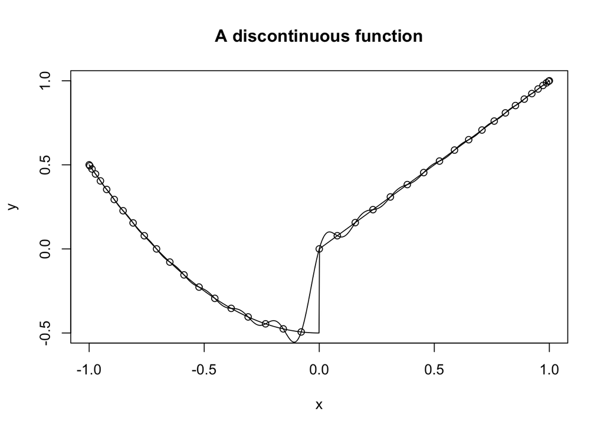

```r
f <- function(x){
  y <- x+0
  y[x<0] <- -0.5+x[x<0]^2
  return(y)
}
x_pts <- cos(0:40 * pi / 40)
y_pts <- f(x_pts)
x <- seq(-1,1,length=1000)
y <- f(x)
p <- my.2BC(y_pts, x)
plot(x,y,'l',main="A discontinuous function")
lines(x, p, 'l')
points(x_pts, y_pts, col='black')
```

The Chebyshev polynomial approximations will converge slowly since the function is not smooth. Let $p(x)$ be the polynomial of degree $40$ that matches $f(x)$ on the 41-point Chebyshev grid. Plot $p(x)$ and $f(x)$ on the same plot, using different colors. On the same plot, include the points where $f = p$, that is, the points $(x_j, f(x_j))$ for $x_j = \cos(j \pi / 40)$.

### Q2 Extrema problem

Let
$$f(x) = \sin(6x) + 0.75
\sin(60\exp(x)).$$
The graph is rather wiggly:

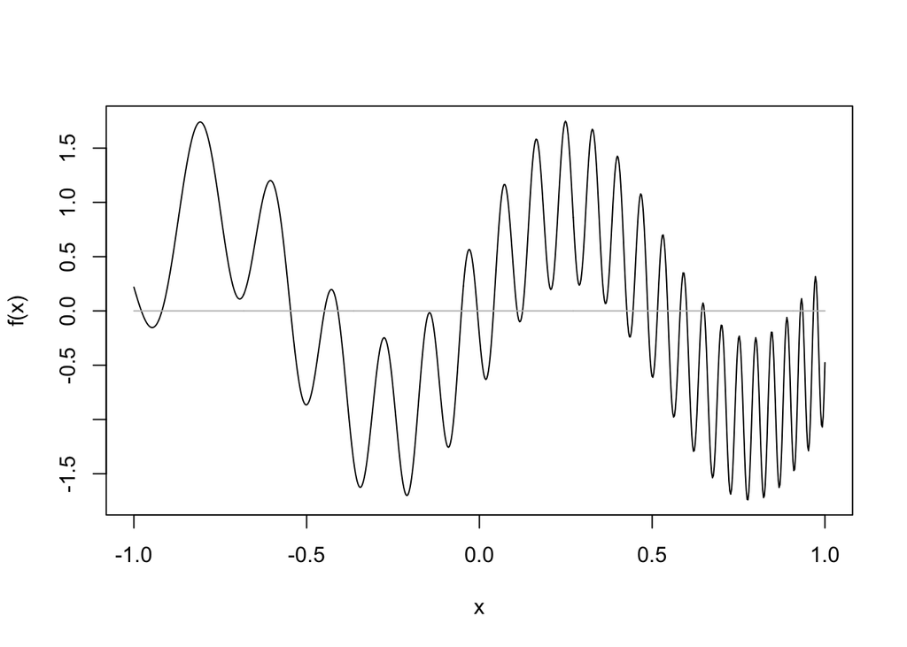

```r
x <- seq(-1,1,length=800)
f <- function(x) {sin(6*x) + 0.75 *sin(60*exp(x))}
plot(x,f(x),'l')
lines(x,0*x,col="gray")
```

Make another version of this plot that also has red dots at all of the extrema (local maxes and mins) that lie above the gray line $y=0$.

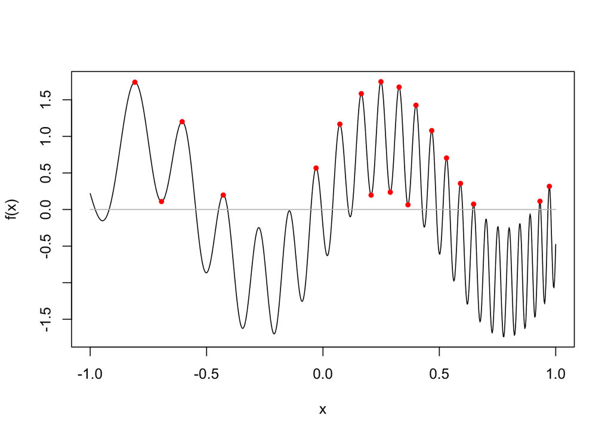

```r
x <- seq(-1,1,length=800)
f <- function(x) {sin(6*x) + 0.75 *sin(60*exp(x))}
plot(x,f(x),'l')
lines(x,0*x,col="gray")
n <- 500 # degree 500 approximating polynomial
x <- cos(0:n * pi / n) # the special grid of x values
y <- f(x) # the corresponding y values
c <- my.dct(y) # the Chebyshev coefficients
cd <- my.cheb.diff(c)
n <- 499
roots <- my.roots(cd)
for (root in roots) {
  if (f(root) > 0 && root > -1 && root < 1) {
    points(root, f(root), col='red', pch=20)
  }
}
```

```r
roots[1]
```

```
## [1] -1.010313
```

### Q3 A scary integral

Normally we apply Clenshaw-Curtis integration to integrals on the interval $[-1,1]$. Here’s an example of something a bit more general: let’s find
$$\int_{0}^\infty
\frac{4t^3+6t^2-1}{2+\sqrt{t}}e^{-t} \,dt.$$
To deal with the nonstandard interval, we can change variables! Let
$$t = \frac{x+1}{1-x}$$
so that $t$ goes from $0$ to $\infty$ while $x$ is going from $-1$ to $1$. Then we can find $dt = \frac{2}{(1-x)^2}\,dx$ and change the whole problem to an integral in $x\in[-1,1]$ instead of $t\in[0,\infty)$. Now the new problem can be treated with Clenshaw-Curtis integration! Try it with 10, 50, and 250 points and report your answers. *Hint: you might get an issue where your integrand becomes NaN for $x = 1$, since that makes $t=\infty$. To figure out what to do about this, I suggest making a graph of the integrand for $x\in[-1,1]$.*

```r
t <- function(x) {
  return ((x+1)/(1-x))
}

f <- function(x) {
  t <- t(x)
  return ((4*(t^3) + 6*(t^2) - 1) * exp(-t) * (2/(1-x)^2) / (2 + t^0.5))
}

integrand <- function(c) {
  res <- 0
  for (i in 1:length(c)) {
    if (i %% 2 == 1) {
      res <- res + (2 / (1-(i-1)^2))*c[i]
    }
  }
  return(res)
}
n <- 10
x <- cos(1:n * pi / n) # the special grid of x values
y <- f(x) # the corresponding y values
c <- my.dct(y) # the Chebyshev coefficients
inte <- integrand(c)
inte
```

```
## [1] 8.320257
```

```r
n <- 50
x <- cos(1:n * pi / n) # the special grid of x values
y <- f(x) # the corresponding y values
c <- my.dct(y) # the Chebyshev coefficients
inte <- integrand(c)
inte
```

```
## [1] 9.091189
```

```r
n <- 250
x <- cos(1:n * pi / n) # the special grid of x values
y <- f(x) # the corresponding y values
c <- my.dct(y) # the Chebyshev coefficients
inte <- integrand(c)
inte
```

```
## [1] 9.157075
```

### Q4 Fast decay = smooth graph

How smooth is the horizon? In mountainous areas, the horizon might be rough and wiggly, with many sharp corners; in other parts of the world you might see smooth hills or even a flat, straight line. The smoothness or roughness of a function can be explored quantitatively through its Chebyshev coefficients. If the coefficients $c_j$ of a Chebyshev series $\sum_{j=0}^\infty$ decay quickly, the graph of the function should be smooth. If the coefficients decay slowly, the graph will be rougher. Let’s make a graph illustrating this general principle. First we’ll create some randomized Chebyshev coefficients that decay at different rates:

```r
c.1 <- rnorm(1500)*(1:1500)^(-1)    # slow decay
c.2 <-rnorm(1500)*(1:1500)^(-1.5)
c.3 <- rnorm(1500)*(1:1500)^(-2)
c.4 <- rnorm(1500)*(1:1500)^(-2.5)
c.5 <- rnorm(1500)*(1:1500)^(-3)    # fast decay
```

Interpret the vectors created in the last cell as the Chebyshev coeffients of five different polynomials. Plot all five of them together on one plot. Use different colors and make a legend so that we can see which is which. Is it true that the graph corresponding to **c.5** is the smoothest while the graph corresponding to **c.1** is the roughest?

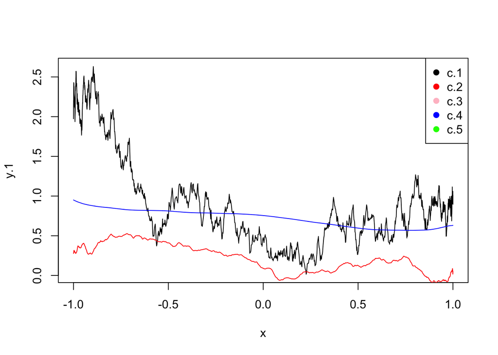

```r
x <- cos(1:1500 * pi / 1500) # the special grid of x values
y.1 <- my.idct(c.1)
y.2 <- my.idct(c.2)
y.3 <- my.idct(c.3)
y.4 <- my.idct(c.4)
y.5 <- my.idct(c.5)
plot(x, y.1, 'l')
lines(x, y.2, col='red')
lines(x, y.3, col='pink')
lines(x, y.4, col='blue')
lines(x, y.5, col='green')
legend("topright", legend = c("c.1", "c.2", "c.3", "c.4","c.5"), col = c("black", "red", "pink", "blue", "green"), pch = 19)
```

### Q5 Zero-padding before IDCT

Let $p(x) = 14T_6(x) - 100T_4(x)+2T_3(x)+18T_2(x)-9T_1(x)+1$. Here is a mysterious code fragment that creates vectors **y.1** and **y.2**:

```r
cc <- c(1,-9,18,2,-100,0,14)
y.1 <- my.idct(cc)
cc.with.zeros <- c(cc,rep(0,94))
y.2 <- my.idct(cc.with.zeros)
```

Note that `cc` and `cc.with.zeros` both express the same Chebyshev series; the only difference is that `cc` truncates after $c_6=14$, whereas `cc.with.zeros` continues with $c_7=0$, $c_8=0$, $\cdots$, $c_{100}=0$.

First, note that `y.1[6] = 53.79422863406`. Show that you understand what the IDCT does by writing your own code to recreate this number, using the vector `cc` but not using the IDCT.

```r
# Define the Chebyshev coefficients
cc <- c(1, -9, 18, 2, -100, 0, 14)
x <- cos(5*pi/6)
t <- rep(0, 7)
t[1] <- 1
t[2] <- x
for (i in 3:length(t)) {
  t[i] <- 2*x*t[i-1] - t[i-2]
}
res <- t(t) %*% cc
res
```

```
##          [,1]
## [1,] 53.79423
```

Next, note that `y.2[28]=93.150093709829`. Show that you understand what the IDCT does by writing your own code to recreate this number, using the vector `cc` but not using the IDCT.

```r
cc.with.zeros <- c(cc,rep(0,94))
x <- cos(27*pi/100)
t <- rep(0, 101)
t[1] <- 1
t[2] <- x
for (i in 3:length(t)) {
  t[i] <- 2*x*t[i-1] - t[i-2]
}
res <- t(t) %*% cc.with.zeros
res
```

```
##          [,1]
## [1,] 93.15009
```

### Q6 Multiplying two Chebyshev series

Let $p(x)$ be a polynomial of degree $n$ and let $q(x)$ be a polynomial of degree $m$. Then we know that $r(x) = p(x) q(x)$ is a polynomial of degree $n+m$. Fill in the rest of this function to obtain the Chebyshev coefficients for $r(x)$ from the coefficients for $p$ and $q$.

```r
cheb.mult <- function(cp,cq){
  n <- length(cp) - 1
  m <- length(cq) - 1
  # ... create yp and yq
  yp <- my.idct(cp)
  yq <- my.idct(cq)
  t <- m+n
  X <- cos(0:t * pi / t)
  yp <- my.2BC(yp, X)
  yq <- my.2BC(yq, X)
  cr <- my.dct(yp*yq)
  return(cr)
}
round(cheb.mult(c(0,0,10),c(0,0,0,10)))
```

```
## [1]  0 50  0  0  0 50
```

You can check your function by testing that $p(x)=10T_2(x)$ and $q(x)=10T_3(x)$ give $p(x)q(x) = 50T_1(x) + 50T_5(x)$. That is, `cheb.mult(c(0,0,10),c(0,0,0,10))` should return `[0,50,0,0,0,50]`.

### Q7 Nested Chebyshev grids

Here’s the Chebyshev grid with 34 points:

```r
x34 <- cos(0:33 * pi / 33)

j <- 35

while (length(setdiff(x34, cos(0:(j-1) * pi / (j-1)))) > 0) {
  j <- j + 1
}

print(j)
```

```
## [1] 67
```

What is the smallest $j>34$ such that the $j$-point Chebyshev grid includes all of the values in `x34`?

The smallest $j > 34$ such that the $j$-point Chebyshev grid includes all of the values in `x34` will be 67.